# Lesson 3 Problem Set

### Diamonds Quiz

You should notice that the diamonds data set will be listed as a ‘Promise’ in the workspace. This is a special object in R, and you need to **run a command on the data to fully load the data set.**

Some data sets come with R. You can load these data sets by typing the command **data(DATA_SET_NAME)**.

You can learn more about the diamonds data set by typing ?diamonds.

Read the help file to determine the best color for the diamonds data set. When you run, **diamonds$color**, you will notice that the levels of color are set as D < E < F < …

This does not indicate that D is the worst color but rather an ordering to the colors.

```r
# You need to run these commands each time you launch RStudio to access the diamonds data set. RStudio won't remember which packages and data sets you loaded unless you change your preferences or save your workspace.
setwd("~/Desktop/Nanodegrees/Data Analyst/Task 4/Data Analysis with R/Explore One Variable/Files/")
library(ggplot2) # must load the ggplot package first
data(diamonds) # loads the diamonds data set since it comes with the ggplot package
summary(diamonds)
```

```
##      carat               cut        color        clarity
##  Min.   :0.2000   Fair     : 1610   D: 6775   SI1    :13065
##  1st Qu.:0.4000   Good     : 4906   E: 9797   VS2    :12258
##  Median :0.7000   Very Good:12082   F: 9542   SI2    : 9194
##  Mean   :0.7979   Premium  :13791   G:11292   VS1    : 8171
##  3rd Qu.:1.0400   Ideal    :21551   H: 8304   VVS2   : 5066
##  Max.   :5.0100                     I: 5422   VVS1   : 3655
##                                     J: 2808   (Other): 2531
##      depth           table           price             x
##  Min.   :43.00   Min.   :43.00   Min.   :  326   Min.   : 0.000
##  1st Qu.:61.00   1st Qu.:56.00   1st Qu.:  950   1st Qu.: 4.710
##  Median :61.80   Median :57.00   Median : 2401   Median : 5.700
##  Mean   :61.75   Mean   :57.46   Mean   : 3933   Mean   : 5.731
##  3rd Qu.:62.50   3rd Qu.:59.00   3rd Qu.: 5324   3rd Qu.: 6.540
##  Max.   :79.00   Max.   :95.00   Max.   :18823   Max.   :10.740
##
##        y                z
##  Min.   : 0.000   Min.   : 0.000
##  1st Qu.: 4.720   1st Qu.: 2.910
##  Median : 5.710   Median : 3.530
##  Mean   : 5.735   Mean   : 3.539
##  3rd Qu.: 6.540   3rd Qu.: 4.040
##  Max.   :58.900   Max.   :31.800
##
```

```r
# Number of ordered factors
str(diamonds)
```

```
## Classes 'tbl_df', 'tbl' and 'data.frame':    53940 obs. of  10 variables:
##  $ carat  : num  0.23 0.21 0.23 0.29 0.31 0.24 0.24 0.26 0.22 0.23 ...
##  $ cut    : Ord.factor w/ 5 levels "Fair"<"Good"<..: 5 4 2 4 2 3 3 3 1 3 ...
##  $ color  : Ord.factor w/ 7 levels "D"<"E"<"F"<"G"<..: 2 2 2 6 7 7 6 5 2 5 ...
##  $ clarity: Ord.factor w/ 8 levels "I1"<"SI2"<"SI1"<..: 2 3 5 4 2 6 7 3 4 5 ...
##  $ depth  : num  61.5 59.8 56.9 62.4 63.3 62.8 62.3 61.9 65.1 59.4 ...
##  $ table  : num  55 61 65 58 58 57 57 55 61 61 ...
##  $ price  : int  326 326 327 334 335 336 336 337 337 338 ...
##  $ x      : num  3.95 3.89 4.05 4.2 4.34 3.94 3.95 4.07 3.87 4 ...
##  $ y      : num  3.98 3.84 4.07 4.23 4.35 3.96 3.98 4.11 3.78 4.05 ...
##  $ z      : num  2.43 2.31 2.31 2.63 2.75 2.48 2.47 2.53 2.49 2.39 ...
```

```r
# Read more about data set to find out best color
?diamonds
```

#### How many obervations are in the data set?

53940

#### How many variables are in the data set?

10

#### How many ordered factors are in the data set?

3

#### What letter best represents the best color for a diamond?

D

### Price Histogram Quiz

#### Create a histogram of the price of all the diamonds in the diamond data set.

```r
# Find column names of the diamonds
names(diamonds)
```

```
##  [1] "carat"   "cut"     "color"   "clarity" "depth"   "table"   "price"
##  [8] "x"       "y"       "z"
```

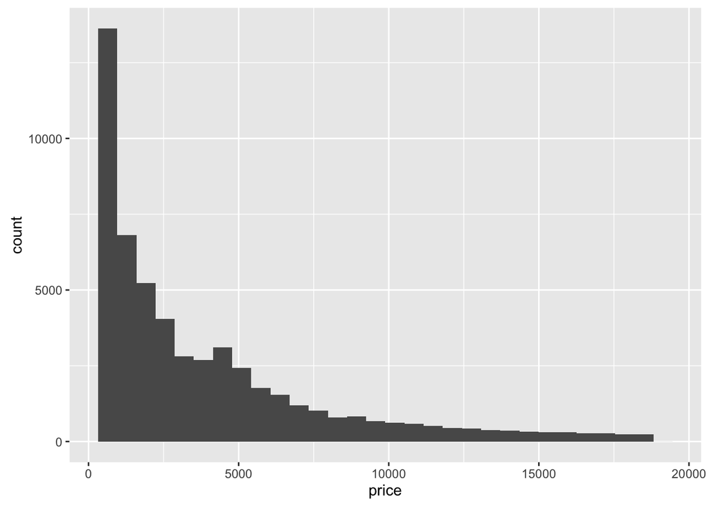

```r
# Histogram of diamonds in the data Set
qplot(x = price, data = diamonds)
```

### Price Histogram Summary Quiz

```r
# Summary stats for price
summary(diamonds$price)
```

```
##    Min. 1st Qu.  Median    Mean 3rd Qu.    Max.
##     326     950    2401    3933    5324   18820
```

```r
# IQR Range
5324 - 950
```

```
## [1] 4374
```

#### Describe the shape and center of the price distribution. Include summary statistics like the mean and median.

The price distribution is positively skewed and long tailed. There is a large peak at around 1000 and it steadily declines from there.

The Median is 2401 and the Mean is 3933.

The IQR is between 5324 and 950 = 4374.

### Diamond Counts Quiz

```r
# Price < 500
dim(subset(diamonds, price < 500))
```

```
## [1] 1729   10
```

```r
# Price < 250
dim(subset(diamonds, price < 250))
```

```
## [1]  0 10
```

```r
# Price >= 15000
dim(subset(diamonds, price >= 15000))
```

```
## [1] 1656   10
```

#### How many diamonds cost less than $500?

1729

#### How many diamonds cost less than $250?

0

#### How many diamonds cost $15000 or more?

1656

### Cheaper Diamonds Quiz

Explore the largest peak in the price histogram you created earlier.

Try limiting the x-axis, altering the bin width, and setting different breaks on the x-axis.

There won’t be a solution video for this question so go to the discussions to share your thoughts and discover what other people find.

You can save images by using the **ggsave()** command.

**ggsave()** will save the last plot created.

**ggsave** currently recognises the extensions eps/ps, tex (pictex), pdf, jpeg, tiff, png, bmp, svg and wmf (windows only).

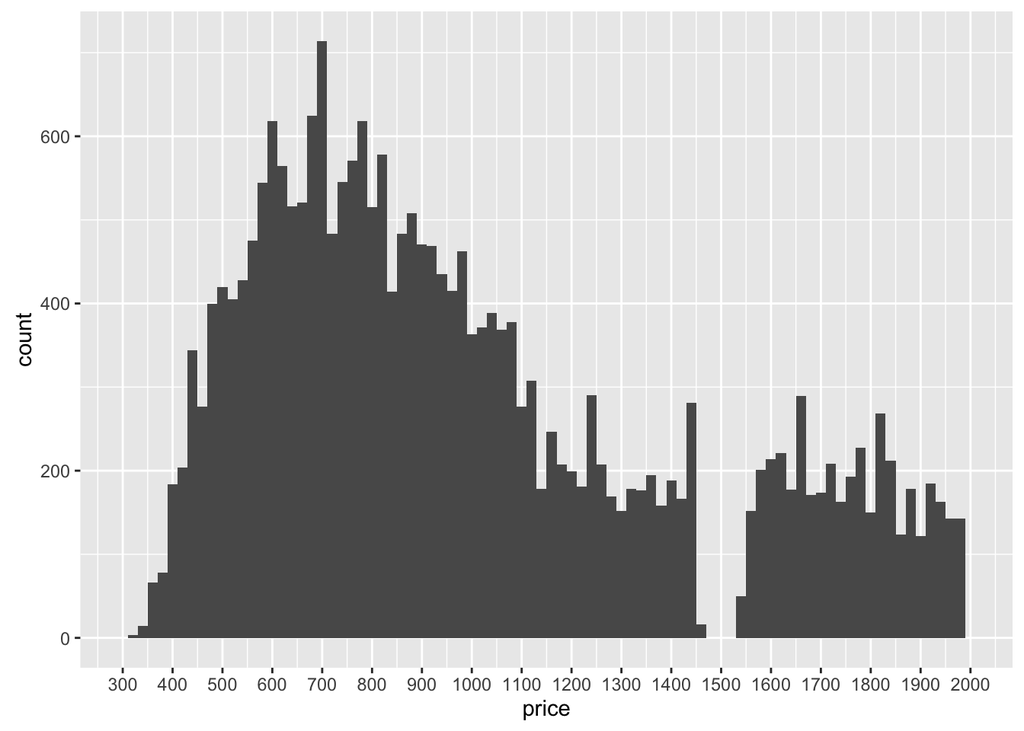

```r
qplot(x = price,
      data = diamonds,
      binwidth = 20) +
  scale_x_continuous(limits = c(300,2000),breaks = seq(300,2000,100))
```

```r
ggsave('priceHistogram.png')
```

#### Insight

For diamonds that cost less than $2,000, the most common price of a diamond is around $700 with the mode being $605 (binwidth = 1).

### Price by Cut Histogram Quiz

Break out the histogram of diamond prices by cut.

You should have five histograms in separate panels on your resulting plot.

```r
# Finding stats of price by cut for diamonds
by(diamonds$price, diamonds$cut, summary)
```

```
## diamonds$cut: Fair
##    Min. 1st Qu.  Median    Mean 3rd Qu.    Max.
##     337    2050    3282    4359    5206   18570
## --------------------------------------------------------
## diamonds$cut: Good
##    Min. 1st Qu.  Median    Mean 3rd Qu.    Max.
##     327    1145    3050    3929    5028   18790
## --------------------------------------------------------
## diamonds$cut: Very Good
##    Min. 1st Qu.  Median    Mean 3rd Qu.    Max.
##     336     912    2648    3982    5373   18820
## --------------------------------------------------------
## diamonds$cut: Premium
##    Min. 1st Qu.  Median    Mean 3rd Qu.    Max.
##     326    1046    3185    4584    6296   18820
## --------------------------------------------------------
## diamonds$cut: Ideal
##    Min. 1st Qu.  Median    Mean 3rd Qu.    Max.
##     326     878    1810    3458    4678   18810
```

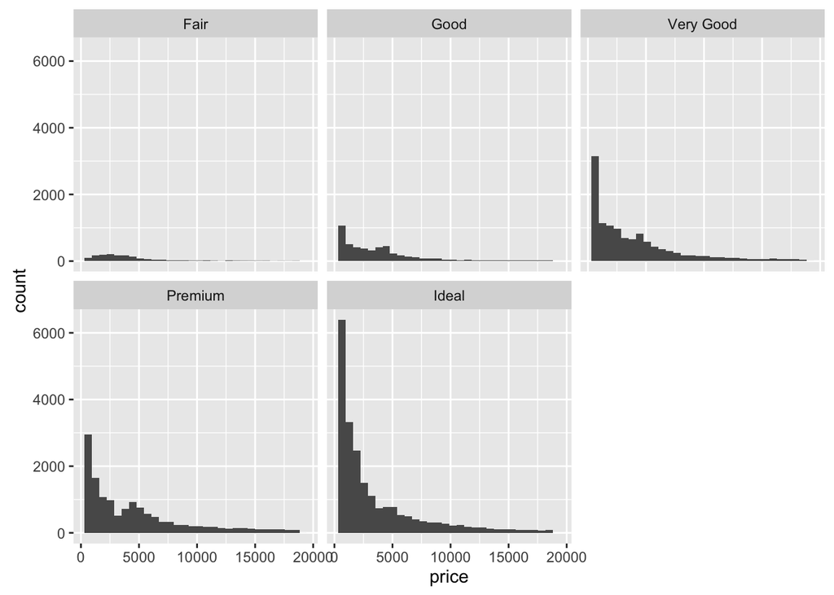

```r
# Use facet wrap to get price by cut
qplot(x = price, data = subset(diamonds, !is.na(cut)))  +
  facet_wrap(~cut)
```

#### Insight

Other than the distribution for fair, all the other cuts have similar distributions.

### Price by Cut Quiz

```r
# Finding stats of price by cut for diamonds
by(diamonds$price, diamonds$cut, summary)
```

```
## diamonds$cut: Fair
##    Min. 1st Qu.  Median    Mean 3rd Qu.    Max.
##     337    2050    3282    4359    5206   18570
## --------------------------------------------------------
## diamonds$cut: Good
##    Min. 1st Qu.  Median    Mean 3rd Qu.    Max.
##     327    1145    3050    3929    5028   18790
## --------------------------------------------------------
## diamonds$cut: Very Good
##    Min. 1st Qu.  Median    Mean 3rd Qu.    Max.
##     336     912    2648    3982    5373   18820
## --------------------------------------------------------
## diamonds$cut: Premium
##    Min. 1st Qu.  Median    Mean 3rd Qu.    Max.
##     326    1046    3185    4584    6296   18820
## --------------------------------------------------------
## diamonds$cut: Ideal
##    Min. 1st Qu.  Median    Mean 3rd Qu.    Max.
##     326     878    1810    3458    4678   18810
```

```r
# Use max/min to get accurate data - summary does some rounding.
by(diamonds$price, diamonds$cut, max)
```

```
## diamonds$cut: Fair
## [1] 18574
## --------------------------------------------------------
## diamonds$cut: Good
## [1] 18788
## --------------------------------------------------------
## diamonds$cut: Very Good
## [1] 18818
## --------------------------------------------------------
## diamonds$cut: Premium
## [1] 18823
## --------------------------------------------------------
## diamonds$cut: Ideal
## [1] 18806
```

```r
by(diamonds$price, diamonds$cut, min)
```

```
## diamonds$cut: Fair
## [1] 337
## --------------------------------------------------------
## diamonds$cut: Good
## [1] 327
## --------------------------------------------------------
## diamonds$cut: Very Good
## [1] 336
## --------------------------------------------------------
## diamonds$cut: Premium
## [1] 326
## --------------------------------------------------------
## diamonds$cut: Ideal
## [1] 326
```

#### What cut has the highest priced diamond?

Premium

#### What cut has the lowest priced diamond?

Premium and Ideal

#### What cut has the lowest median price?

Ideal

### Scales and Multiple Histograms Quiz

The ‘Fair’ and ‘Good’ diamonds appear to have different distributions compared to the better cut diamonds. They seem somewhat uniform on the left with long tails on the right.

Let’s look in to this more.

Look up the documentation for **facet_wrap** in R Studio. Then add a parameter to **facet_wrap** so that the y-axis in the histograms is not fixed. You want the y-axis to be different for each histogram.

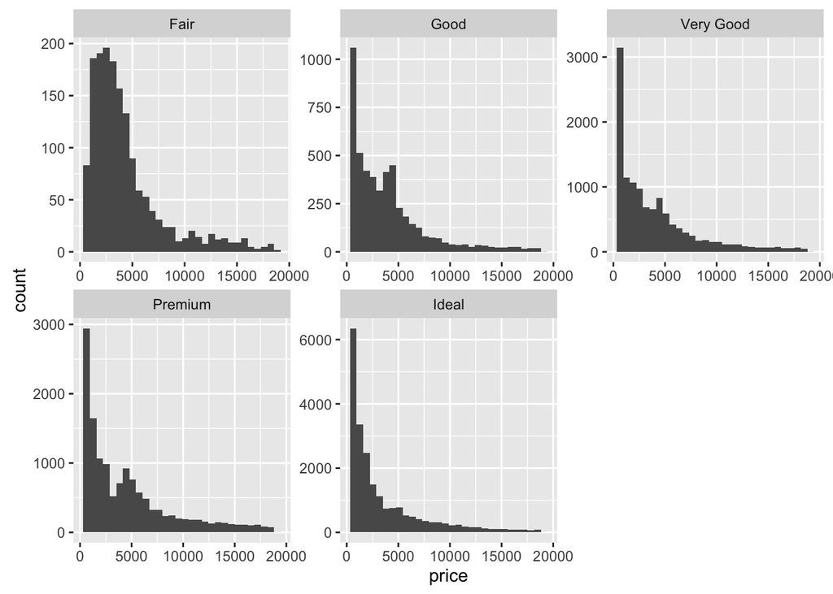

```r
# Documentation for facet_wrap
?facet_wrap

# Making y axis different for each histogram
qplot(x = price, data = subset(diamonds, !is.na(cut))) +
  facet_wrap(~cut, scales='free')
```

#### Answer

Use **scales=‘free’**. Read the free scales documentation for more info.

It’s a good idea to consider the scales when you create plots.

### Price per Carat by Cut Quiz

Create a histogram of price per carat and facet it by cut. You can make adjustments to the code from the previous exercise to get started.

Adjust the bin width and transform the scale of the x-axis using log10.

**Hint 1:** You use the price and carat variables in the parameter for x. What expression gives you price per carat?

**Hint 2:** For long tailed distributions, you can add a ggplot layer such as **scale_x_log10()** to transform the variable.

```r
names(diamonds)
```

```
##  [1] "carat"   "cut"     "color"   "clarity" "depth"   "table"   "price"
##  [8] "x"       "y"       "z"
```

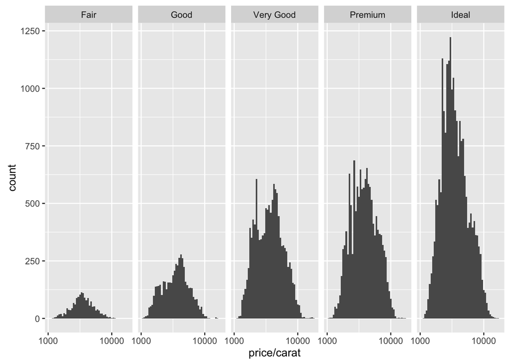

```r
# Price/carat facetted by cut. Using binwidth < 1 because it's in log terms.
qplot(x = price/carat, data = subset(diamonds, !is.na(cut)), binwidth = 0.025) +
  scale_x_log10() +
  facet_grid(~cut)
```

#### Answer

I found normal-ish distributions and a slightly bimodal distribution for Very Good cuts.

### Price Box Plots Quiz

Investigate the price of diamonds using box plots, numerical summaries, and one of the following categorical variables: cut, clarity, or color.

There won’t be a solution video for this question so go to the discussions to share your thoughts and discover what other people find.

You can save images by using the **ggsave()** command.

**ggsave()** will save the last plot created.

**ggsave** currently recognises the extensions eps/ps, tex (pictex), pdf, jpeg, tiff, png, bmp, svg and wmf (windows only).

**For boxplots, we use y parameter for the continuous data and the x parameter for the categorical data.**

```r
# Numerical Summary of Price by Cut
by(diamonds$price, diamonds$cut, summary)
```

```
## diamonds$cut: Fair
##    Min. 1st Qu.  Median    Mean 3rd Qu.    Max.
##     337    2050    3282    4359    5206   18570
## --------------------------------------------------------
## diamonds$cut: Good
##    Min. 1st Qu.  Median    Mean 3rd Qu.    Max.
##     327    1145    3050    3929    5028   18790
## --------------------------------------------------------
## diamonds$cut: Very Good
##    Min. 1st Qu.  Median    Mean 3rd Qu.    Max.
##     336     912    2648    3982    5373   18820
## --------------------------------------------------------
## diamonds$cut: Premium
##    Min. 1st Qu.  Median    Mean 3rd Qu.    Max.
##     326    1046    3185    4584    6296   18820
## --------------------------------------------------------
## diamonds$cut: Ideal
##    Min. 1st Qu.  Median    Mean 3rd Qu.    Max.
##     326     878    1810    3458    4678   18810
```

```r
# Boxplot For Cut
cutplot <- qplot(x = cut, y = price,
      data = subset(diamonds, !is.na(cut)),
      geom = 'boxplot')

# Numerical Summary of Price by Clarity
by(diamonds$price, diamonds$clarity, summary)
```

```
## diamonds$clarity: I1
##    Min. 1st Qu.  Median    Mean 3rd Qu.    Max.
##     345    2080    3344    3924    5161   18530
## --------------------------------------------------------
## diamonds$clarity: SI2
##    Min. 1st Qu.  Median    Mean 3rd Qu.    Max.
##     326    2264    4072    5063    5777   18800
## --------------------------------------------------------
## diamonds$clarity: SI1
##    Min. 1st Qu.  Median    Mean 3rd Qu.    Max.
##     326    1089    2822    3996    5250   18820
## --------------------------------------------------------
## diamonds$clarity: VS2
##    Min. 1st Qu.  Median    Mean 3rd Qu.    Max.
##     334     900    2054    3925    6024   18820
## --------------------------------------------------------
## diamonds$clarity: VS1
##    Min. 1st Qu.  Median    Mean 3rd Qu.    Max.
##     327     876    2005    3839    6023   18800
## --------------------------------------------------------
## diamonds$clarity: VVS2
##    Min. 1st Qu.  Median    Mean 3rd Qu.    Max.
##   336.0   794.2  1311.0  3284.0  3638.0 18770.0
## --------------------------------------------------------
## diamonds$clarity: VVS1
##    Min. 1st Qu.  Median    Mean 3rd Qu.    Max.
##     336     816    1093    2523    2379   18780
## --------------------------------------------------------
## diamonds$clarity: IF
##    Min. 1st Qu.  Median    Mean 3rd Qu.    Max.
##     369     895    1080    2865    2388   18810
```

```r
# Boxplot For Clarity
clarityplot <- qplot(x = clarity, y = price,
      data = subset(diamonds, !is.na(clarity)),
      geom = 'boxplot')

# Numerical Summary of Price by Color
by(diamonds$price, diamonds$color, summary)
```

```
## diamonds$color: D
##    Min. 1st Qu.  Median    Mean 3rd Qu.    Max.
##     357     911    1838    3170    4214   18690
## --------------------------------------------------------
## diamonds$color: E
##    Min. 1st Qu.  Median    Mean 3rd Qu.    Max.
##     326     882    1739    3077    4003   18730
## --------------------------------------------------------
## diamonds$color: F
##    Min. 1st Qu.  Median    Mean 3rd Qu.    Max.
##     342     982    2344    3725    4868   18790
## --------------------------------------------------------
## diamonds$color: G
##    Min. 1st Qu.  Median    Mean 3rd Qu.    Max.
##     354     931    2242    3999    6048   18820
## --------------------------------------------------------
## diamonds$color: H
##    Min. 1st Qu.  Median    Mean 3rd Qu.    Max.
##     337     984    3460    4487    5980   18800
## --------------------------------------------------------
## diamonds$color: I
##    Min. 1st Qu.  Median    Mean 3rd Qu.    Max.
##     334    1120    3730    5092    7202   18820
## --------------------------------------------------------
## diamonds$color: J
##    Min. 1st Qu.  Median    Mean 3rd Qu.    Max.
##     335    1860    4234    5324    7695   18710
```

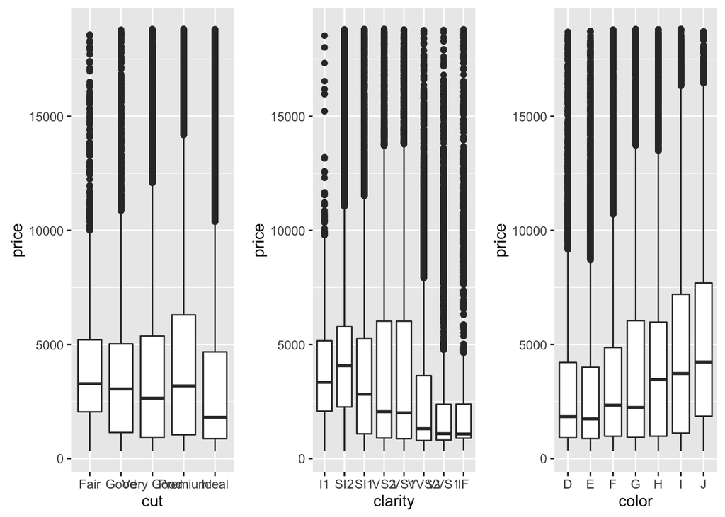

```r
# Boxplot For Color
colorplot <- qplot(x = color, y = price,
      data = subset(diamonds, !is.na(color)),
      geom = 'boxplot')

# install.packages('gridExtra')
library(gridExtra)

grid.arrange(cutplot, clarityplot, colorplot, ncol = 3)
```

```r
ggsave('priceBoxPlots.png')
```

### Interquartile Range - IQR Quiz

You can use the function **IQR()** to find the interquartile range. Pass it a subset of the diamonds data frame.

For example…

```
IQR(subset(diamonds, price <1000)$price)
```

Remember subset returns a data frame so we need to use **$price** on the end to access that variable.

```r
# Price range for middle 50% of diamonds with color D & IQR
by(diamonds$price, diamonds$color == 'D', summary)
```

```
## diamonds$color == "D": FALSE
##    Min. 1st Qu.  Median    Mean 3rd Qu.    Max.
##     326     958    2503    4042    5527   18820
## --------------------------------------------------------
## diamonds$color == "D": TRUE
##    Min. 1st Qu.  Median    Mean 3rd Qu.    Max.
##     357     911    1838    3170    4214   18690
```

```r
by(diamonds$price, diamonds$color == 'D', IQR)
```

```
## diamonds$color == "D": FALSE
## [1] 4569
## --------------------------------------------------------
## diamonds$color == "D": TRUE
## [1] 3302.5
```

```r
# Price range for middle 50% of diamonds with color J & IQR
by(diamonds$price, diamonds$color == 'J', summary)
```

```
## diamonds$color == "J": FALSE
##    Min. 1st Qu.  Median    Mean 3rd Qu.    Max.
##     326     939    2351    3856    5219   18820
## --------------------------------------------------------
## diamonds$color == "J": TRUE
##    Min. 1st Qu.  Median    Mean 3rd Qu.    Max.
##     335    1860    4234    5324    7695   18710
```

```r
by(diamonds$price, diamonds$color == 'J', IQR)
```

```
## diamonds$color == "J": FALSE
## [1] 4280
## --------------------------------------------------------
## diamonds$color == "J": TRUE
## [1] 5834.5
```

#### What is the price range for the middle 50% of diamonds with color D?

**First Quartile**: 911

**Third Quartile**: 4214

#### What is the price range for the middle 50% of diamonds with color J?

**First Quartile**: 1860

**Third Quartile**: 7695

#### What is the IQR for diamonds with the best color?

3302.5

#### What is the IQR for diamonds with the worst color?

5834.5

### Price per Carat Box Plots by Color Quiz

Investigate the price per carat of diamonds across the different colors of diamonds using boxplots.

There won’t be a solution video for this question so go to the discussions to share your thoughts and discover what other people find.

You can save images by using the **ggsave()** command.

**ggsave()** will save the last plot created.

**ggsave** currently recognises the extensions eps/ps, tex (pictex), pdf, jpeg, tiff, png, bmp, svg and wmf (windows only).

**Hint: Use price and carat as a ratio in the parameter y to create the box plots.**

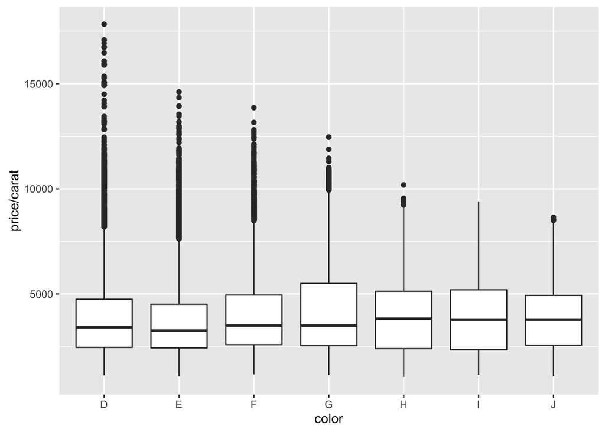

```r
qplot(x = color, y = price/carat,
      data = subset(diamonds, !is.na(color)),
      geom = 'boxplot')
```

#### Answer

The plot shows that the median price/carat are all similar. The price/carat for the color group D (the best color group) has a lot more outliers however, and this reduces the worse the color of the diamond gets.

### Carat Frequency Polygon Quiz

Investigate the weight of the diamonds (carat) using a frequency polygon.

Use different bin widths to see how the frequency polygon changes.

```r
names(diamonds)
```

```
##  [1] "carat"   "cut"     "color"   "clarity" "depth"   "table"   "price"
##  [8] "x"       "y"       "z"
```

```r
summary(diamonds$carat)
```

```
##    Min. 1st Qu.  Median    Mean 3rd Qu.    Max.
##  0.2000  0.4000  0.7000  0.7979  1.0400  5.0100
```

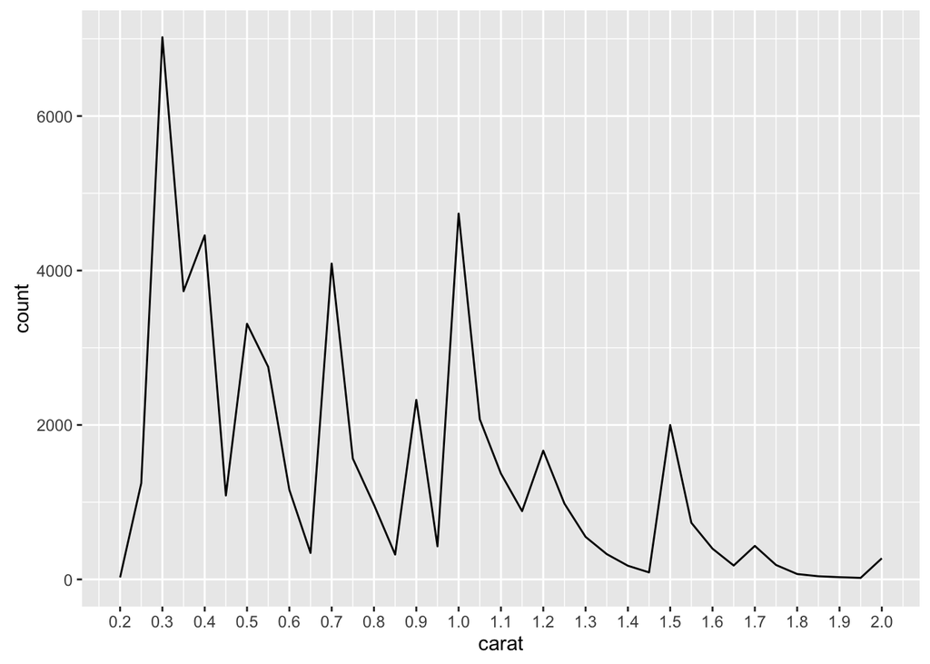

```r
# Plotting the frequency polygon
qplot(x = carat,
      data = subset(diamonds, !is.na(carat)),
      binwidth = 0.05,
      geom = 'freqpoly') +
      scale_x_continuous(limits = c(0.2,2),
                         breaks = seq(0.2,2,0.1))
```

#### What carat size has a count greater than 2000?

0.3 & 1.01 (from the selected options).

### Data Wrangling with R Quiz

**Data munging** or **data wrangling** can take up much of a data scientist’s or data analyst’s time. There are two R packages that make these tasks easier in R: **tidyr** and **dplyr**.

**tidyr** - a package that reshapes the layout of your data

**dplyr** - a package that helps you transform tidy, tabular data

[Review Data Wrangling in R](https://s3.amazonaws.com/udacity-hosted-downloads/ud651/DataWranglingWithR.pdf) to get a sense of how these packages allow you to manipulate data. You can use these packages to help you in the next programming task and in your future investigations.

You may also download this useful [Data Wrangling Cheat Sheet](http://www.rstudio.com/wp-content/uploads/2015/02/data-wrangling-cheatsheet.pdf). There are some other useful cheat sheets at [RStudio](https://www.rstudio.com/resources/cheatsheets/).

### Gapminder Data Quiz

The Gapminder website contains over 500 data sets with information about the world’s population. Your task is to download a data set of your choice and create 2-5 plots that make use of the techniques from Lesson 3.

You might use a simple histogram, a boxplot split over a categorical variable, or a frequency polygon. The choice is yours!

You can find a link to the Gapminder website in the Instructor Notes.

Once you’ve completed your investigation, create a post in the discussions that includes:

1. any questions you answered, your observations, and summary statistics
2. snippets of code that created the plots
3. links to the images of your plots

[Gapminder Data](https://www.gapminder.org/data/)

[Hans Rosling’s 200 Countries, 200 Years, 4 Minutes](https://www.youtube.com/watch?v=jbkSRLYSojo)

[Save plots](http://docs.ggplot2.org/current/ggsave.html) using ggsave().

The following command may be helpful for some of the Gapminder Data sets, once it’s been converted to csv format: **read.csv(‘data.csv’, header = T, row.names = 1, check.names = F)**. You may want to look at additional function arguments in the help file for the read.table() family for additional tools that can help you read in data.

If you want to exchange the rows and columns of your dataframe, it will also be useful to know the **transpose function, t()**.

```r
## Seeing what files are in my folder
list.files()
```

```
##  [1] "Friends Birthdays.ics"
##  [2] "friends_birthdays.csv"
##  [3] "health_spending_per_person_(US $).xlsx"
##  [4] "indicator_health_spending_per_person_(US $).csv"
##  [5] "lesson3_student.html"
##  [6] "lesson3_student.rmd"
##  [7] "priceBoxPlots.png"
##  [8] "priceHistogram.png"
##  [9] "Problem_Set_files"
## [10] "Problem_Set.html"
## [11] "Problem_Set.rmd"
## [12] "pseudo_facebook.tsv"
```

```r
## Installing relevant packages
#install.packages('tidyr')
#install.packages('dplyr')

library(tidyr)
library(dplyr)
```

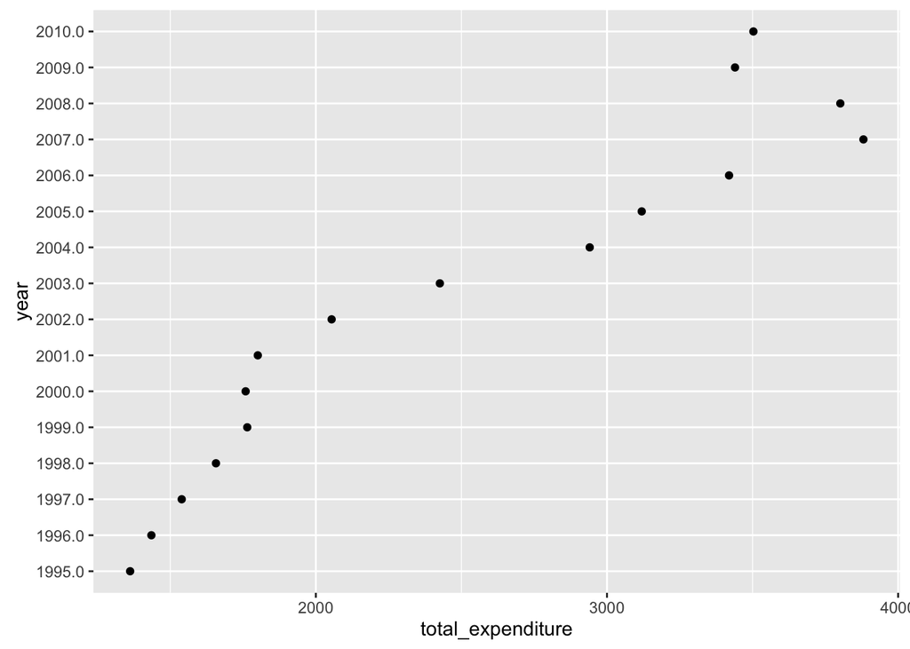

```r
# Reading excel file into R
library('rio')
data = import('health_spending_per_person_(US $).xlsx')

# See example below for help.
  #install.packages("devtools")
  #devtools::install_github("rstudio/EDAWR")
  #library(EDAWR)
  #?cases
  #cases$country
  #names(cases)[-1]
  #unlist(cases[1:3, 2:4])
  #View(cases)
  #dim(cases)

# Name of countries (i.e. row index)
country = data$`Per capita total expenditure on health at average exchange rate (US$)`

# Years (i.e. column headers)
year = names(data)[-1]

# Entries for column. In unlist, first set of values is for row length and second is for column width.
n = unlist(data[1:262, 2:17])

# Tidying data
tidied = gather(data, "year", "total_expenditure", 2:17)

# Changing column names in tidied.
colnames(tidied) <- c("country","year","total_expenditure" )

## Total expenditure by country
# by(tidied$total_expenditure, tidied$country, summary)

## Expenditure by United Kingdom Histogram
qplot(x = total_expenditure, y =year,
      data = subset(tidied, country=="United Kingdom"))
```

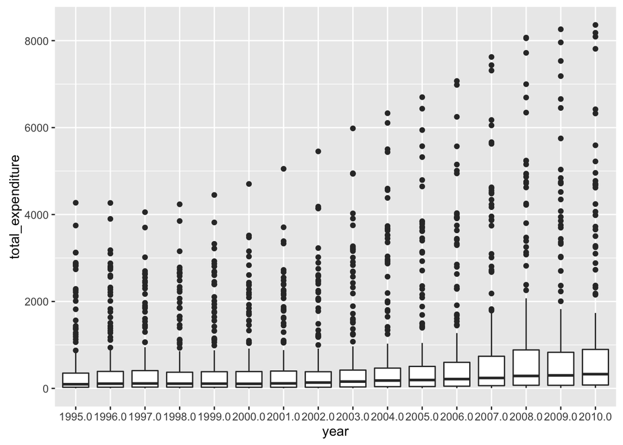

```r
## Boxplot of Total expenditure over years
qplot(x = year , y = total_expenditure,
      data = tidied,
      geom = 'boxplot')
```

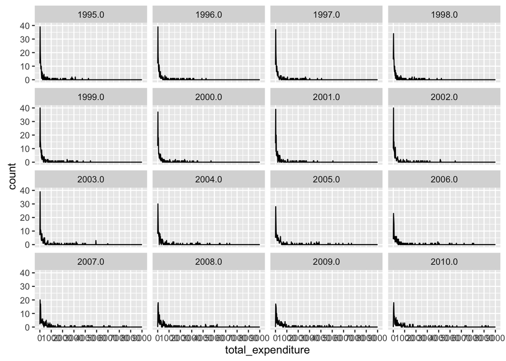

```r
## Frequency Polygon of total_expenditure Histogram
qplot(x = total_expenditure,
      data = subset(tidied, !is.na(total_expenditure)),
      binwidth = 20,
      geom = 'freqpoly') +
  scale_x_continuous(limits = c(0, 9000), breaks = seq(0, 9000, 1000)) +
  facet_wrap(~year)
```

### Exploring Your Friends’ Birthdays Quiz

Your task is to investigate the distribution of your friends’ birth months and days.

We encourage you to use the [lubridate](https://cran.r-project.org/web/packages/lubridate/vignettes/lubridate.html) package for working with dates. Read over the documentation in RStudio and search for examples online if you need help.

You’ll need to export your Facebooks friends’ birthdays to a csv file. You may need to create a calendar of your Facebook friends’ birthdays in a program like Outlook or Gmail and then export the calendar as a csv file.

Once you load the data into R Studio, you can use the **strptime()** function to extract the birth months and birth days. We recommend looking up the documentation for the function and finding examples online.

[Download Your Friends’ Birthdays from Facebook](https://www.facebook.com/help/152652248136178/)

[Date Formats in R](https://www.r-bloggers.com/date-formats-in-r/)

[Export a Google Calendar](https://support.google.com/calendar/answer/37111?hl=en)

[Google Calendar to Excel: Free Trial](https://www.gcal2excel.com/)

```r
list.files()
```

```
##  [1] "Friends Birthdays.ics"
##  [2] "friends_birthdays.csv"
##  [3] "health_spending_per_person_(US $).xlsx"
##  [4] "indicator_health_spending_per_person_(US $).csv"
##  [5] "lesson3_student.html"
##  [6] "lesson3_student.rmd"
##  [7] "priceBoxPlots.png"
##  [8] "priceHistogram.png"
##  [9] "Problem_Set_files"
## [10] "Problem_Set.html"
## [11] "Problem_Set.rmd"
## [12] "pseudo_facebook.tsv"
```

```r
#install.packages('lubridate')
library(lubridate)
# Reading in csv file and checking column names
fb <- read.csv('friends_birthdays.csv', header = TRUE)
names(fb)
```

```
## [1] "Title"    "Start"    "End"      "Duration"
```

```r
# Dropping end and duration columns.
fb$End <- NULL
fb$Duration <- NULL

# Changing time, 05/19/2017
fb$Start <- strptime(fb$Start, format = "%m/%d/%Y")
fb$month = month(fb$Start)
fb$day = day(fb$Start)

head(fb)
```

```
##                           Title      Start month day
## 1     Keaghan Durant's birthday 2016-09-28     9  28
## 2        Will Downes's birthday 2016-09-28     9  28
## 3 Alice Louise Wager's birthday 2016-09-28     9  28
## 4       Jack Huggins's birthday 2016-09-28     9  28
## 5        Timothy Kok's birthday 2016-09-29     9  29
## 6  Reuben Rory Blake's birthday 2016-09-29     9  29
```

```r
## People who share my birthday
subset(fb$Title, fb$Start == '2017-05-31')
```

```
## [1] Haris Ali's birthday     Jamie Potter's birthday
## [3] Sim Virdi's birthday     Bekah Mikhael's birthday
## 598 Levels:  'Fasil ˚\u035c˚ Zaman''s birthday ... Zoe Carter's birthday
```

```r
## Which month contains the most number of birthdays?
xtabs(~month,fb)
```

```
## month
##  1  2  3  4  5  6  7  8  9 10 11 12
## 53 44 49 49 53 48 50 44 59 58 46 46
```

```r
lm <- table(fb$month)
names(lm[which.max(lm)])
```

```
## [1] "9"
```

```r
## How many birthdays are in each month?
table(fb$month)
```

```
##
##  1  2  3  4  5  6  7  8  9 10 11 12
## 53 44 49 49 53 48 50 44 59 58 46 46
```

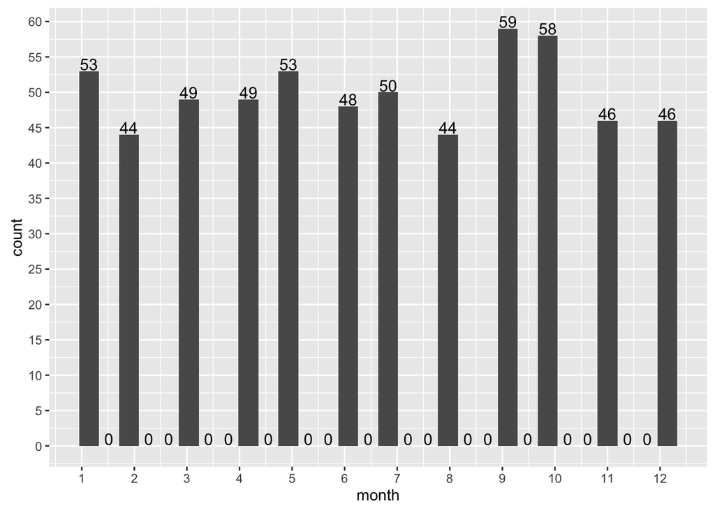

```r
qplot(x = month, data = fb) +
  scale_x_continuous(breaks=seq(0,12,1)) +
  scale_y_continuous(breaks = seq(0, 60, 5)) +
  stat_bin(aes(label=..count..), vjust=-.1, geom="text", position="identity", size=4)
```

```r
## Which day of the year has the most number of birthdays?
df <- data.frame(date = fb$Start,
                 year = year(fb$Start),
                 month = fb$month,
                 day = fb$day,
                 month_day = as.numeric(format(fb$Start, format = "%j")))

md <- table(df$month_day)
names(md[which.max(md)])
```

```
## [1] "258"
```

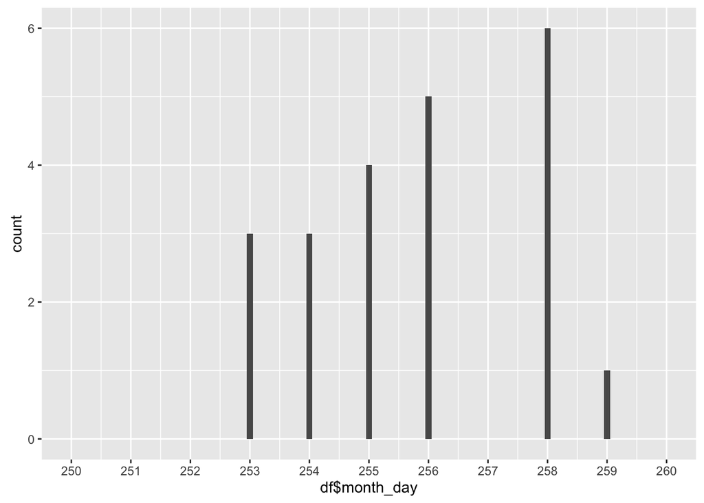

```r
# Double checking with a plot & Zooming in
qplot(x = df$month_day,
      data = df,
      binwidth = 0.1) +
  scale_x_continuous(limits = c(250,260), breaks = c(250:260))
```

```r
# Finding the date which is 15th September
subset(df, month_day == 258)
```

```
##           date year month day month_day
## 573 2017-09-15 2017     9  15       258
## 574 2017-09-15 2017     9  15       258
## 575 2017-09-15 2017     9  15       258
## 576 2017-09-15 2017     9  15       258
## 577 2017-09-15 2017     9  15       258
## 578 2017-09-15 2017     9  15       258
```

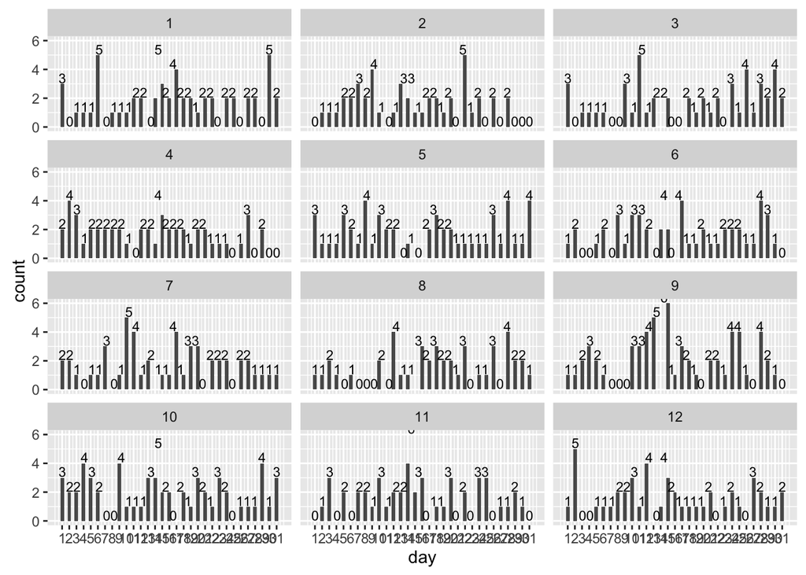

```r
## Do you have at least 365 friends that have birthdays on everyday of the year?
qplot(x = day, binwidth = 0.5,
      data = subset(fb, !is.na(day))) +
  scale_x_continuous(breaks = 1:31) +
  facet_wrap(~month, ncol = 3) +
  stat_bin(aes(label=..count..), vjust=-.1, geom="text", position="identity", size=3)
```

#### Which month contains the most number of birthdays?

September

#### How many birthdays are in each month?

1 2 3 4 5 6 7 8 9 10 11 12 53 44 49 49 53 48 50 44 59 58 46 46

#### Which day of the year has the most number of birthdays?

September 15th (See plot above or look at calculations)

#### Do you have at least 365 friends that have birthdays on everyday of the year?

No (See Plot Above)